# Genre classification with SVM

Here we show that vectors of word frequencies hold more information than a simple authorship. Using roughly the same methods and features we can tackle the problem of genre classification, restating our questions on similarities and differences on the meta-level of genre instead of an author.

### Corpus

We use 18th century French drama for this experiment that is labeled as either Comedy or Tragedy.

- Data come from open-source digital collection [Théâtre Classique](http://www.theatre-classique.fr/pages/programmes/PageEdition_18.php).
- 249 dramatic texts which had words “comédie” or “tragédie” in the genre definitition (not everything that was availiable made it’s way in our corpus: texts too short were trimmed out)

Classic French drama comes from a literary system that was controlled by **rigid normative aesthetics**, **distinct public expectations** and even **space itself** (genres were differently represented in different theaters). 17-18th century French theater was an icon of play stratification across genres for the whole Europe. Obviously, we expect very high accuracy in distinguishing between Comedies & Tragedies - but would a simple word frequencies be enough?

## Method 1: classify() with “stylo” package

`{stylo}` package has a `classify()` function with GUI for supervised classifications. Several algorithms are available (including classification by nearest neighbor), but we’re using SVM here.

**NB!!!** Function looks in “primary_set” folder for training set and “secondary_set” for test set. Make sure you have these folders in your working directory. These folders should be also filled with data (which maybe not very convenient)

```r
library(stylo)

svm_results=classify(gui = F, # you can obviously run plain classify() function to set everything in GUI
         method="svm",
         kernel="linear",
         cost=1)

summary(svm_results) ## see what's inside in the classify() call output
```

```
##
## Function call:
## classify(gui = F, method = "svm", kernel = "linear", cost = 1)
##
## Available variables:
##
##            distance.table  final distances between each pair of samples
##                  expected  ground truth, or a vector of expected classes
##                  features  features (e.g. words, n-grams, ...) applied to data
##    features.actually.used  features (e.g. frequent words) actually analyzed
##     frequencies.both.sets  frequencies of words/features accross the corpus
##      frequencies.test.set  frequencies of words/features in the test set
##  frequencies.training.set  frequencies of words/features in the training set
##                 predicted  a vector of classes predicted by the classifier
##              success.rate  percentage of correctly guessed samples
##
## These variables can be accessed by typing e.g.:
##
## svm_results$distance.table
```

```r
svm_results$success.rate ## what's final accuracy
```

```
##
## ---------------------------------------
## percentage of correctly guessed samples
## ---------------------------------------
##
## 95.34884
```

`classify()` also outputs several files to your working directory: in `final_results.txt` you can access both accuracy and misclassified texts.

`classify()` is basically a wrapper around SVM model in `{e1071}` package - so we can work with it directly. It potentially allows more control over the corpus and makes it easier to split/manipulate data

## Intermezzo: Manual Corpus Preparation

It should be vaguely familiar at this point:

#### Unzip the corpus…

```r
unzip("fr18_drama.zip")
```

#### List files….

```r
library(tidyverse)
library(tidytext)
## list files in fr18 corpus
files = list.files("fr18_drama", full.names = T)

head(files)
```

```
## [1] "fr18_drama/C_1701_boursault_esope.txt"
## [2] "fr18_drama/C_1701_dancourt_colin-maillard.txt"
## [3] "fr18_drama/C_1703_dufresny_fauxhonnetehomme.txt"
## [4] "fr18_drama/C_1704_dancourt_galantjardinier.txt"
## [5] "fr18_drama/C_1704_regnard_legataire.txt"
## [6] "fr18_drama/C_1705_regnard_menechmes.txt"
```

#### Make tibble and read texts as character strings into it…

```r
corpus = tibble(title = files,
                 text = sapply(files, read_file)) %>%
  mutate(title = str_replace(title, ".*/(.*?).txt", "\\1"),
         text = str_replace_all(text,"'|’", " "))  # some very basic cleaning

corpus[1:5,]
```

```
## # A tibble: 5 x 2
##   title                    text
##   <chr>                    <chr>
## 1 C_1701_boursault_esope   "Que direz-vous, messieurs, à moins d être indulgent…
## 2 C_1701_dancourt_colin-m… "Tatigué, Monsieur, vous devenez une marchandise bia…
## 3 C_1703_dufresny_fauxhon… "Oui Frosine, oui, Monsieur Ariste est un vrai homme…
## 4 C_1704_dancourt_galantj… "Oh ! \nPour cela, monsieur Dubuisson, vous prenez b…
## 5 C_1704_regnard_legataire "Bonjour, Crispin, bonjour. \nBonjour, belle Lisette…
```

#### Arrange words according to their frequency rank…

```r
rank = corpus %>%
  mutate(text=str_replace_all(text, "'", " ")) %>%
  #tokenize by word -> new column "word" out of column "text"
  unnest_tokens(input = text, output = word, token = "words") %>%
    #count & sort
  count(word, sort = T) %>%
  select(-n) %>%
  head(5000) # cut wordlist to 5000 MFWs
```

20 most frequent words in French drama corpus:

| word | de | vous | je | et | que | le | est | à | l | il | la | un | en | qu | d | ne | ce | les | qui | n |
| --- | --- | --- | --- | --- | --- | --- | --- | --- | --- | --- | --- | --- | --- | --- | --- | --- | --- | --- | --- | --- |

#### Calculate frequencies per each text and spread to wide “document-term matrix”-like form…

```r
freqs = corpus %>%
  mutate(text=str_replace_all(text, "'", " ")) %>%
  unnest_tokens(input = text, output = word, token = "words") %>%
  right_join(rank,by="word") %>%
  count(title, word) %>% # count words within each text
  group_by(title) %>%
  mutate(n = n/sum(n)) %>% # because of group_by() will sum word counts only within titles -> we get relative frequencies
  rename(text_title = title) %>%
  mutate(word = factor(word, levels = rank$word)) %>% #reorder words by their rank
  spread(key = "word", value="n",fill = 0) # make the table wider
```

| text_title | de | vous | je | et | que | le | est | à | l |
| --- | --- | --- | --- | --- | --- | --- | --- | --- | --- |
| C_1701_boursault_esope | 0.0296759 | 0.0276259 | 0.0216224 | 0.0236724 | 0.0223545 | 0.0202558 | 0.0169856 | 0.0190843 | 0.0170832 |
| C_1701_dancourt_colin-maillard | 0.0331889 | 0.0322376 | 0.0287496 | 0.0180742 | 0.0232534 | 0.0158546 | 0.0225135 | 0.0190255 | 0.0106754 |
| C_1703_dufresny_fauxhonnetehomme | 0.0300016 | 0.0372434 | 0.0350947 | 0.0135286 | 0.0268980 | 0.0166322 | 0.0194175 | 0.0175871 | 0.0100271 |
| C_1704_dancourt_galantjardinier | 0.0351870 | 0.0274360 | 0.0233760 | 0.0175935 | 0.0252215 | 0.0157480 | 0.0230069 | 0.0171014 | 0.0109498 |
| C_1704_regnard_legataire | 0.0317207 | 0.0258489 | 0.0272530 | 0.0257850 | 0.0175517 | 0.0165305 | 0.0147434 | 0.0156370 | 0.0132116 |

#### Scale frequencies…

Let’s skip first 100 most frequent words to exclude functions words that may be important for individual style, but not necessarily genre signal.

```r
## scale desired amount of MFWs ()
z = freqs[,102:301] %>% as.matrix() %>% scale() %>% as_tibble()
```

#### Combine back together, define class (genre) labels…

```r
## combine it back with titles
z_fin = freqs[,1] %>%
  ungroup() %>%
  mutate(text_id = row_number())  %>% # text id's for later splitting
  bind_cols(z) %>%
  mutate(text_title = str_extract(text_title, "^.")) %>% # extract first character from title (C or T) as genre label
  rename(text_genre=text_title)
```

## Method 2. svm() from “e1071”

Now when we have represented texts by feature vectors, we can start splitting our data to test and train sets. Before that, however, let’s check how two genres are represented in our corpus

```r
library(e1071)

z_fin$text_genre %>% table()
```

```
## .
##   C   T
## 154  95
```

We have a disparity here: comedies are over-represented. It’s generally a good idea to keep data points per class (genre) equal, so algorithm would have equal possibilities for learning features of each class. Let’s downsample comedies making them not more frequent than tragedies. After downsampling we can split data to training and test: let’s make it with a proportion of 60/40 - a bit funnier than usual 75/25 used everywhere in machine learning.

```r
set.seed(789) # seed for reproducibility

n = min(table(z_fin$text_genre)) # what is the value of the less frequent class

## in what proportion split to training and test sets (roughly 60% of texts will go to training)
train_size = round(n*0.60)
test_size = n - train_size


train_set = z_fin %>%
  group_by(text_genre) %>%
  sample_n(train_size) # sample n times per each group (genre)

test_set = z_fin %>%
  anti_join(train_set, by="text_id") %>% # 1. remove already sampled training set from the data
  group_by(text_genre) %>%
  sample_n(test_size)  # 2. sample again the test per each genre
```

Now we can fit SVM model to our training data (learn genres). We are using linear kernel, and relatively low cost value (it determines how hard margin violations are punished)

```r
svm_model <-svm(as.factor(text_genre)~.,  # we try to predict genre with all words (GENRE ~ WORDS), so we take all columns as predictor variables, we use . to select all data
                data=train_set %>% select(-text_id), # fit on train data, remove ids,
            method="C-classification",
            kernel="linear",
            cost=1,
            scale=T)

summary(svm_model)
```

```
##
## Call:
## svm(formula = as.factor(text_genre) ~ ., data = train_set %>% select(-text_id),
##     method = "C-classification", kernel = "linear", cost = 1, scale = T)
##
##
## Parameters:
##    SVM-Type:  C-classification
##  SVM-Kernel:  linear
##        cost:  1
##
## Number of Support Vectors:  29
##
##  ( 15 14 )
##
##
## Number of Classes:  2
##
## Levels:
##  C T
```

### Feature importance

`summary()` gives us some info on the fitted model, but the variable `svm_model` holds even more of that (try, for example to access this variable through `$` sign).

Using the information from Support Vectors and their relations to features + the coefficient that give us an idea of the hyperplane slope we can compute feature weights. This gives us a nice insight to model performance and feature contribution to class distinctiveness.

```r
### compute features weights (multiply coefficients by support vectors distances to features)
w = t(svm_model$coefs) %*% svm_model$SV
```

| moins | cet | ou | jamais | voilà | seigneur | dit | ciel | veux | ont | voir | yeux | fils | toujours | êtes |
| --- | --- | --- | --- | --- | --- | --- | --- | --- | --- | --- | --- | --- | --- | --- |
| -0.011 | -0.01 | 0.019 | 0.027 | 0.01 | -0.034 | 0.007 | -0.017 | 0.042 | -0.032 | 0.03 | -0.011 | -0.009 | -0.009 | -0.012 |

So, which words contribute most to differences in Tragedy and Comedy according to fitted SVM? We can interpret weights that are higher than zero as important for class “comedy”, while lower than zero weights would associate with “tragedy”.

Hey, but *how do we know* that? We are doing binary classification (on two classes). Because the reference (first) class in our summary is “C” - which is comedy, so positive values associate with importance for this genre. Negative values, therefore, *negatively* associate with Comedy… which means they associate with Tragedy (remember, a binary classification!).

This means we can annotate features accordingly and display most important features for each class/genre and learn something of how SVM learned differences between Comedy & Tragedy.

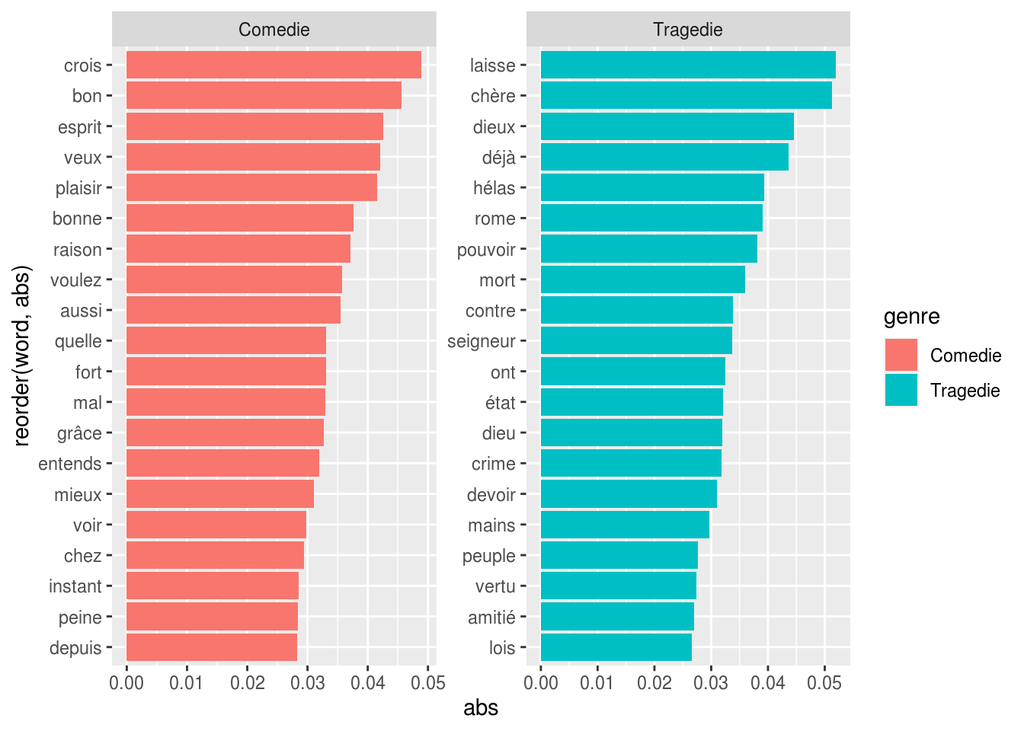

```r
tibble(weight=w[1,], word=colnames(w)) %>%  # construct a tibble from weights
  mutate(genre = case_when(weight > 0 ~ "Comedie", # if weight > 0 - put a Comedie label
                           weight < 0 ~ "Tragedie")) %>% # weight < 0 - put a Tragedie label
  group_by(genre) %>%
  mutate(abs=abs(weight)) %>% # take absolute values
  top_n(20,abs) %>%  # take 20 most distinctive features per each genre

  ggplot(aes(reorder(word,abs),abs,fill=genre)) + geom_col() + # plot
  coord_flip() +
  facet_wrap(~genre,scales="free")
```

### Predict classes for the test set

Finally we can use our fitted model to predict unseen data (test set) - and see how well our model performs.

```r
### now predict classes from unseen test set with the model we have

prediction <- predict(svm_model, test_set %>% select(-text_id))

# final confusion matrix
table(test_set$text_genre, prediction)
```

```
##    prediction
##      C  T
##   C 37  1
##   T  1 37
```

As you see, this untuned raw model performs quite well! Out of 76 dramas in the test set only 1 tragedy and 1 comedy were misclassified.  
This gives us a rough **accuracy** of the model (total number - misclassification cases / total number): around **97.3%**

### Method 3. SVM with “tidymodels” workflow

Now, admittedly using `svm()` from `{e1071}` requires a bit of meddling and hacking. Recently a meta-package `{tidymodels}` for statistical and supervised started to gain popularity because how explicit it makes the modeling process and how easy it can be to setup tuning and tweaking models.  
Roughly speaking, `tidymodels` provides an uniform way to build an instruction of a model and then execute it when fitting the model. Generally each “instruction” or “workflow” is build out of two modules:

1. **Data recipe**. Setting up dependent variables and predictors, recording the steps that you take to prepare data for the model;
2. **Model specification**. Description of the model you use, setting up it source (“engine”) and parameters.

A recipe and a model specs are then combined into one “workflow” - the whole instruction list, which can be later fitted, cross-validated, resampled, etc. Current `tidymodels` together with package `textrecipes` provide in-workflow way of dealing with textual data - so all the steps that we take manually (tokenization, filtering, counts), could be frist recorded in a reciepe and then executed when model is fitted.

It almost makes a model building with `tidymodels` an exercise in arranging LEGO blocks in the right order: it may bring benefits (clear structure, modularity, high control of the fitting), but also limitations (dependence on some third-party defined functions to do specific things, lack of preprocessing control, lack of model interpretability).

To learn more about predictive text modeling with `tidymodels` in R check [Supervised Machine Learning for Text Analysis in R](https://smltar.com/index.htmls)

We will need following libraries:

```r
library(tidymodels)
library(textrecipes)
library(kernlab)
```

Let’s start with some minor changes to our `corpus` variable:

```r
### tweak our existing corpus and make classes equal
corpus = corpus %>%
  mutate(title=str_extract(title,"^.")) %>%
  rename(genre = title) %>%
  group_by(genre) %>%
  sample_n(95) %>%  # make T & C equally represented
  ungroup()
```

Now `tidymodels` functions could be utilized for splitting data into training and test test

```r
### split data to test & train
genre_split = initial_split(corpus, strata="genre",prop = 6/10)

genre_train = training(genre_split)
genre_test = testing(genre_split)

dim(genre_split)
```

```
##   analysis assessment          n          p
##        114         76        190          2
```

We can start assembling set of instructions for data preparations. It’s a recipe where we put steps that *should* be taken with the original data.

```r
genres_recipe =
  recipe(genre~text,data=genre_train) %>% # genre~text formula means that we try to predict genre with text column
  step_tokenize(text) %>%  # now we define how to transform text to features. 1. tokenize
  step_tokenfilter(text, # 2. filter tokens. We use words that appear in the corpus at least 10 times
                   min_times = 10,
                   max_tokens = 1000) %>% # use first 1000 most frequent words
  step_tf(text, weight_scheme = "term frequency") %>%  # 3. we calculate relative frequencies of each word to account for different sizes of texts
  step_scale(all_predictors()) # 4. we scale frequencies. because at this points our "text" variable is transformed to matrix with word frequencies, we use "all_predictors()" to apply scaling

genres_recipe
```

```
## Data Recipe
##
## Inputs:
##
##       role #variables
##    outcome          1
##  predictor          1
##
## Operations:
##
## Tokenization for text
## Text filtering for text
## Term frequency with text
## Scaling for all_predictors()
```

Next we define model specifications. We use SVM with polynomial kernel from `kernlab` package. Notice that degree is set to 1: 1-order polynomial is a line, so our kernel is linear. Generally we don’t want to use any kernel tricks with multidimensional text data - so a linear kernel is just fine!

```r
svm_spec <- svm_poly(cost=1,degree = 1) %>% # we use polynomial kernel for SVM with degree of 1 - which means we use linear kernel
  set_mode("classification") %>%
  set_engine("kernlab")
```

Finally we can combine recipe and the model definition into the one “workflow” that keep record of all the things we do for modeling (see it’s output)

```r
genre_svm_wf <- workflow() %>%
  add_recipe(genres_recipe) %>%
  add_model(svm_spec)

genre_svm_wf
```

```
## ══ Workflow ══════════════════════════════════════════════════════════════════════════════════════════════════════════════
## Preprocessor: Recipe
## Model: svm_poly()
##
## ── Preprocessor ──────────────────────────────────────────────────────────────────────────────────────────────────────────
## 4 Recipe Steps
##
## ● step_tokenize()
## ● step_tokenfilter()
## ● step_tf()
## ● step_scale()
##
## ── Model ─────────────────────────────────────────────────────────────────────────────────────────────────────────────────
## Polynomial Support Vector Machine Specification (classification)
##
## Main Arguments:
##   cost = 1
##   degree = 1
##
## Computational engine: kernlab
```

As in all supervised modeling our “test” set is very valuable “unseen” data that we can use only once. To fine-tune the model and test general behavior of our SVM we must rely on “training” set only. There is a well-established procedure of “cross validation” that is used to iteratively fit the model on different sub-training and sub-test sets - in a fashion that all available data is used in training and testing to exclude potential bias in arbitrary data splits.

So before we do the final fit on our test set, let’s use “V-fold cross-validation”. It will “fold” our training set in V number of chunks (we use 10). When we will perform iterative resampling, each of the folds will be used as the test set, while remaining 9 folds will be put to training. In this case all chunks will appear both as training and testing. Luckily with `tidymodels` you can fold data in one line:

```r
genre_folds <- vfold_cv(genre_train,strata = "genre",v = 10)

genre_folds
```

```
## #  10-fold cross-validation using stratification
## # A tibble: 10 x 2
##    splits           id
##    <list>           <chr>
##  1 <split [102/12]> Fold01
##  2 <split [102/12]> Fold02
##  3 <split [102/12]> Fold03
##  4 <split [102/12]> Fold04
##  5 <split [102/12]> Fold05
##  6 <split [102/12]> Fold06
##  7 <split [102/12]> Fold07
##  8 <split [104/10]> Fold08
##  9 <split [104/10]> Fold09
## 10 <split [104/10]> Fold10
```

Finally we can iteratively fit SVM model on folds using the defined workflow:

```r
genre_svm_resamp <- fit_resamples(
  genre_svm_wf,
  genre_folds,
  metrics = metric_set(accuracy), # collect accruacy as model performance metrics
  control = control_resamples(save_pred = TRUE) # save predictions for each fold-fit
)
```

After fitting is done, we can check accuracy and use predictions to construct confusion matrix.

```r
# general accuracy
genre_metrics = collect_metrics(genre_svm_resamp)

# predictions
genre_pred = collect_predictions(genre_svm_resamp)

genre_metrics
```

```
## # A tibble: 1 x 5
##   .metric  .estimator  mean     n std_err
##   <chr>    <chr>      <dbl> <int>   <dbl>
## 1 accuracy binary     0.963    10  0.0212
```

Confusion matrix:

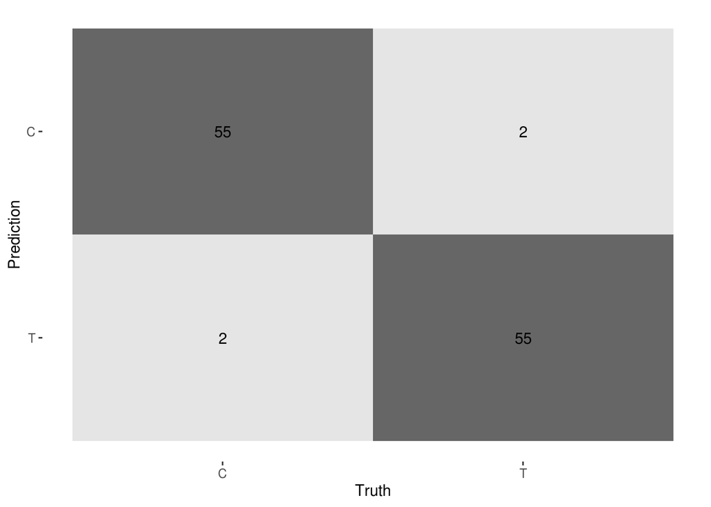

```r
genre_pred %>%
  conf_mat(genre, .pred_class) %>%
  autoplot(type = "heatmap")
```

Ideally now you start working on fine-tuning the model (checking different kernel performances, tuning the cost value, etc.), before going near our test set. We skip this stuff to the very final fit:

```r
final_res <- genre_svm_wf %>%
  last_fit(genre_split, metrics = metric_set(accuracy))

collect_metrics(final_res)
```

```
## # A tibble: 1 x 3
##   .metric  .estimator .estimate
##   <chr>    <chr>          <dbl>
## 1 accuracy binary             1
```